# Ganado Vacuno

Carcaño Garcia Estefania

8 de marzo de 2021

Naturaleza: Las vacas están en la naturaleza y es uno de los primeros animales en ser domesticados por el humano. Son mamíferos, deben de beber mucha agua y come pasto, alfalfa, sorgo y cebada.

Valor de uso: los humanos le han encontrado varios usos a la vaca, desde alimento con su leche y su carne, para el uso en la vestimenta, como lo es la ropa y calzado, prácticamente se dice que se aprovecha a toda la vaca. También la vaca se puede usar como una mascota o utilizada en el deporte de montaje.

Valor de cambio: en México existen dos canales de comercialización de la carne de res: el moderno integrado por los rastros tipo Inspección Federal (TIP) y el tradicional, es decir el que es a menor escala.

Valor: se producen mas de treinta razas diferentes de ganado bovino. Los mayores productores son Veracruz, Jalisco, Chiapas, Chihuahua y Baja California.

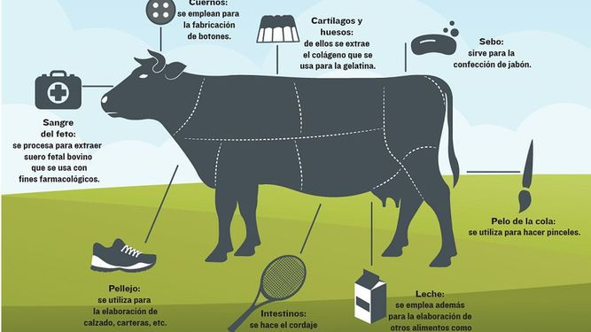

Fuente: (la prensa,2016)

## Bibliografía

1. La prensa. (12 de enero de 2016). La vaca, un animal sin desperdicio. Obtenido de https://www.prensa.com/salud_y_ciencia/vaca-animal-desperdicio_0_4390811003.html#:~:text=La%20vaca%20tambi%C3%A9n%20se%20despoja,para%20la%20industria%2C%20indica%20Ram%C3%ADrez.
2. México, G. d. (s.f.). ¿cómo son las vacas y los toros? . Obtenido de http://siaprendes.siap.gob.mx/contenidos/1/05-vaca/contexto-5.html